# Je fais encore du Python2 en 2024

Pourquoi s’infliger cette douleur ?

Julien Lenormand

# Introduction

## Présentation du speaker

Julien Lenormand

Ingénieur informatique

Pythonista depuis ~2009

J’ai répondu en 2022 à une offre d’emploi pour faire du Python …

2 !

## Minute de silence pour Python2

Il nous a quitté il y a presque 5 ans …

😢

## Petit sondage

- Qui a déjà fait du Python 2 ?
- Qui en a fait il y a moins de 4 ans ?
- Moins d’1 an ?

# Une histoire de Python

## Une longue histoire (versions 0.x à 2.x)

Python démarre en Décembre 1989

rendu public en 1991

2.0 en 2000 ([What’s new ?](https://docs.python.org/3/whatsnew/2.0.html)) :

- passage sur SourceForge pour faciliter la collaboration
- introduction des PEPs ([PEP-1 - PEP Purposes and Guidelines](https://peps.python.org/pep-0001/))
- type Unicode pour les strings
- et bien d’autres choses …

Et les versions s’enchaînent jusqu’à …

- 2.6 en 2008
- 2.7 en 2010, [PEP-373 : dernière de la branche 2.x](http://legacy.python.org/dev/peps/pep-0373/)
- pas de 2.8 ([PEP-404](https://peps.python.org/pep-0404/))

## Une longue histoire (en perspective)

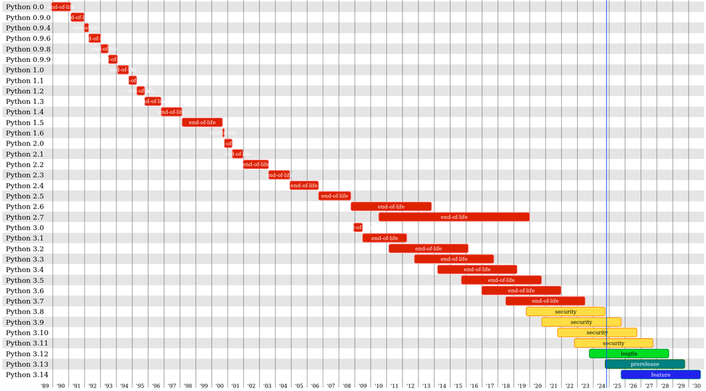

## Une belle histoire (v3.x)

Par rapport à la `2.x` ([PEP 3100](https://peps.python.org/pep-3100/)) :

- division flottante vs entière
- que des *new-style* `class`es
- fonction `print`
- plus de *string exceptions*
- `!=` plutôt que `<>`
- plus de `long`
- **Unicode** par défaut !
- tout est lazy (“x”)
- plus de `raw_input`
- *context manager*: `with`
- *PEP process*
- *implicit namespace packages*
- `set` et `dict` *literals*
- `super()` sans paramètre
- `nonlocal`
- …

Jusqu’à la `3.13` :

- ([3.1](https://docs.python.org/dev/whatsnew/3.1.html)) `OrderedDict`, pure-Python `import`, meilleur `str` des *float*
- ([3.2](https://docs.python.org/dev/whatsnew/3.2.html)) `argparse`, `concurrent.futures`
- ([3.3](https://docs.python.org/dev/whatsnew/3.3.html)) `yield from`, `faulthandler`, `unittest.mock`, `venv`
- ([3.4](https://docs.python.org/dev/whatsnew/3.4.html)) `pip` inclus, `asyncio`, `enum`, `pathlib`
- ([3.5](https://docs.python.org/dev/whatsnew/3.5.html)) *type hints*, *coroutines*, *unpacking* (`*` et `**`)
- ([3.6](https://docs.python.org/dev/whatsnew/3.6.html)) *f-strings*, *async generators and comprehensions*
- ([3.7](https://docs.python.org/dev/whatsnew/3.7.html)) `async`/`await`, `dataclasses`, *ordered* `dict` par défaut
- ([3.8](https://docs.python.org/dev/whatsnew/3.8.html)) *walrus operator* `:=`, `=` des *f-strings*
- ([3.9](https://docs.python.org/dev/whatsnew/3.9.html)) `str.removepre/suffix`, *stdlib* avec des *type hints*
- ([3.10](https://docs.python.org/dev/whatsnew/3.10.html)) *structural pattern matching*, plein de `typing`
- ([3.11](https://docs.python.org/dev/whatsnew/3.11.html)) **speed** ! *exceptions groups/notes*, `tomllib`, encore du `typing`, *deprecations*
- ([3.12](https://docs.python.org/dev/whatsnew/3.12.html)) super *f-strings*, GIL par interpréteur, meilleurs messages d’erreur, toujours du `typing`
- ([3.13](https://docs.python.org/dev/whatsnew/3.13.html)) GIL optionnel, perf (JIT), color support, éternellement du `typing`, *removals*

## Une histoire tragique

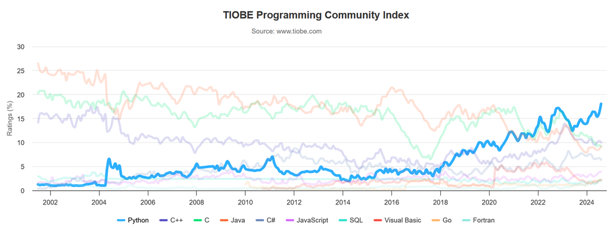

**𝑼𝑵𝑰𝑪𝑶𝑫𝑬**

> L’absolu minimum que chaque dev doit vraiment, absolument savoir à propos d’Unicode et des jeux de caractères (pas d’excuses !)

[Joel Spolsky](https://www.joelonsoftware.com/2003/10/08/the-absolute-minimum-every-software-developer-absolutely-positively-must-know-about-unicode-and-character-sets-no-excuses/)

**Arrêter avec l’ASCII** ([cf](https://peps.python.org/pep-0404/#strings-and-bytes))

# C’est la guerre !

## Premières échafourées

- les versions 3.0 (2008), 3.1 (2009) et 3.2 (2011) :
  - API peu stables, mauvaises perf, et bugs

faible adoption

[PEP 404 - Python2.8 Un-release Schedule](https://peps.python.org/pep-0404/)

## Le conflit s’enlise

> ça marche, pourquoi payer pour changer ?
- [Second-system effect](https://en.wikipedia.org/wiki/Second-system_effect)
- [Things You Should Never Do, Part I](https://www.joelonsoftware.com/2000/04/06/things-you-should-never-do-part-i/) : do not rewrite
- 2.6 EOL en 2013, 2.7 EOL en 2016 (2010) puis EOL en 2020 (2014)

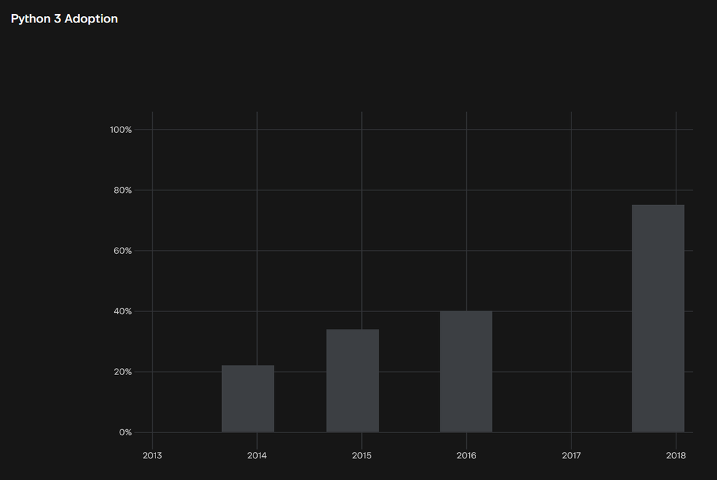

## La course à l’armement

Des efforts sur la compatibilité entre 2.6/7 et 3.x :

- la 3.3 a une syntaxe assez proche des 2.6/2.7
  - front-porting : `u""`
- des backports sont réalisés
  - `from __future__ import` : `division`, `absolute_import`, `print_function`, `unicode_literals`
  - `backports`: `abc`, `csv`, `inspect`, `os`, `range`, `statistics`, …

Des outils pour assister à la migration :

- [`2to3`](https://docs.python.org/fr/3.9/library/2to3.html) : transpile du 2.x en 3.x
- [`python-modernize`](https://github.com/mitsuhiko/python-modernize) : comme 2to3 mais en 3.x compatible 2.x
- [`lib3to6`](https://github.com/mbarkhau/lib3to6) : transpile du 3.x en 2.7
- [`future` : `futurize`/`pasteurize`](https://python-future.org/) : transpile du x.y en 3.x compatible 2.x
- [`3to2`](https://pypi.org/project/3to2/) : pareil que lib3to6
- [`six`](https://pypi.org/project/six/) : couche de compatibilité
- [`nine`](https://github.com/nandoflorestan/nine) : comme six, mais avec le nommage 3.x
- [`eight`](https://github.com/kislyuk/eight) : polyfills automatiques
- [`py3c`](https://py3c.readthedocs.org/en/latest/) : couche de compatibilité pour l’API C
- [`pylint --py3k`](https://pylint.pycqa.org/en/1.9/whatsnew/changelog.html#what-s-new-in-pylint-1-4-0) : warnings sur le 2.x-only
- [`python2.6 -3`](https://pylint.pycqa.org/en/1.9/whatsnew/changelog.html#what-s-new-in-pylint-1-4-0) : warnings sur le 2.x-only

Des guides :

- [PEP 3000, Compatibility and Transition](https://peps.python.org/pep-3000/#compatibility-and-transition) : “The recommended development model …”
- [doc officielle](https://docs.python.org/2/howto/pyporting.html)
- [“conservative”](https://portingguide.readthedocs.io/en/latest/index.html)
- [Python3 Statement - Practicalities](https://python3statement.github.io/practicalities/)
- [Porting to Python 3 Redux](https://lucumr.pocoo.org/2013/5/21/porting-to-python-3-redux/)
- [Twisted’s Reviewer check list](https://github.com/twisted/trac-wiki-archive/blob/trunk/Plan/Python3.mediawiki#reviewer-check-list)

Des listes :

- [Python Clock](https://pythonclock.org/) : Python 2.7 will retire in…
- [Python3 statement](https://python3statement.github.io/) : librairies qui s’engagent à dropper le support de Python2
- [Python3 Wall of Shame](http://web.archive.org/web/20110428094404/http://python3wos.appspot.com/) / [Python3 Wall of Superpowers](http://web.archive.org/web/20210202072503/http://python3wos.appspot.com/) : Top100 PyPI
- [Python3 Readiness](http://web.archive.org/web/20200223050112/http://chhantyal.net/py3readiness/#.XlIHOI3P1S8) : Top 360
- [Can I Use Python 3?](https://github.com/brettcannon/caniusepython3)

## La victoire

pas de spoiler : Python3 a gagné, [Python2 a été sunset](https://www.python.org/doc/sunset-python-2/)

[dernière release de la 2.7 (.18) le 04 Avril 2020, juste avant la PyCon](https://github.com/python/cpython/blob/2.7/Misc/NEWS.d/2.7.18rc1.rst)

- les libs et les applications ont été portées
- la bi-compatibilité a été dropée au fur-et-à-mesure
  - 2016 : Django, 2017 : Pandas, 2018 : Numpy, 2020 : Pip, Celery et Twisted, …
- les environnements (hébergeurs Web, OS, compute, …) ne proposent plus Python2
  - 2018 : RHEL, 2022 : Debian, 2024 : Google App Engine, …
- les conférences n’en parlent plus (🙃)

## Des poches de résistance

- [Ubuntu 18.04 (2018) a son support commercial (incluant Python2) jusqu’en 2028](https://ubuntu.com/blog/18-04-end-of-standard-support)
- [RHEL 7 (2014) a son support commercial (incluant Python2) jusqu’en 2028](https://access.redhat.com/solutions/4455511)
- [PyPy étant basé sur Python2, annonce son support “pour toujours”](https://doc.pypy.org/en/latest/faq.html#which-python-versions-does-pypy-implement)
- [ActiveState continue de proposer une version 2.7 maintenue (payante)](https://www.activestate.com/products/python/python-2-7/)
- [Tauthon est “une sorte de 2.8”](https://github.com/naftaliharris/tauthon/blob/master/README.md)
  - > Ok, bring in the lawyers. - [gvanrossum](https://github.com/naftaliharris/tauthon/issues/47#issuecomment-266470996)
- [OilShell utilise une version forkée et réduite de la 2.7](http://www.oilshell.org/blog/2018/03/04.html#faq)
- [d’après le JetBrains Python Survey 2023, ~6% des Pythonistas continuent de faire du Python2](https://lp.jetbrains.com/python-developers-survey-2023/)

## Le prix de la guerre

- la communauté a été fracturée, et blessée
- prise d’otage ?
  - [non, merci l’Open Source !](https://news.ycombinator.com/item?id=13149508)
- servi d’exemple de ce qu’il en faut PAS faire (cf Perl/Raku)
  - très bon exemple de [network effect](https://en.wikipedia.org/wiki/Network_effect)
- a coûté TRÈS cher ([“billion-dollar mistake”](https://en.wikipedia.org/wiki/Tony_Hoare) ?)
  - Guido reconnaît avoir fait le mauvais choix, avoir sous-estimé les efforts requis
- indicateur de qualité des projets : env (version et dépendances), tests, hacks
  - LES TESTS !!
  - mais aussi les environnements et le packaging
  - et de la non-contribution à l’open-source en général par les entreprises
- indicateur de qualité des dépendances (criticité, [“un random au Nebraska depuis 2003”](https://xkcd.com/2347/))
- la GIL est restée intacte (jusqu’en 3.12~13+)
- il n’y aura jamais de Python 4 ! ([en fait si, en cas de changement majeur de la C-API](https://stackoverflow.com/questions/70557069/have-plans-for-python-4-been-resurrected))

# Ma rencontre avec Python2

début en python3 jusqu’en 2022 Odoo, framework, pas de si grandes différences mais ensuite client qui fait du nucléaire appli en 2.6, sans test auto, avec des hacks de threads et subprocess test manuel uniquement pas de logging, pas de debuggeur

# Conclusion

> [Should I use Python 2 or Python 3 for my development activity?](https://wiki.python.org/moin/Python2orPython3)

> Python 3 is strongly recommended for any new development.
- Python2 n’est pas mort, et ne mourra peut-être pas avant 2040.
- Mais sauf si on me l’impose, Python2 n’est plus un “choix”.
- Je pratique le Python3.6+, avec l’outillage et le typing moderne, et j’en suis heureux.

Et ça s’inscrit dans la raison d’être de Python :

- la glue entre différents langages ayant une C-FFI
- un langage plaisant à utiliser (comparé aux autres)

## Sources

Principales, en plus des liens dans les slides :

- [*.python.org](https://www.python.org/)
- [Guido van Rossum: BDFL Python 3 retrospective](https://www.youtube.com/watch?v=Oiw23yfqQy8)
- [Python FAQ: Why should I use Python 3?](https://eev.ee/blog/2016/07/31/python-faq-why-should-i-use-python-3/)
- [Python 3 Q & A](https://python-notes.curiousefficiency.org/en/latest/python3/questions_and_answers.html)

## Crédits

Images :

- Image de couverture (“Python Meetup Grenoble”) par Pierre-Loïc Bayart
- Image d’introduction (“Python is hell”) par Pierre-Loïc Bayart
- Photo de [Simon Hurry](https://unsplash.com/fr/@bullterriere?utm_content=creditCopyText&utm_medium=referral&utm_source=unsplash) sur [Unsplash](https://unsplash.com/fr/photos/un-ours-assis-par-terre-DxC7IwXQkxI?utm_content=creditCopyText&utm_medium=referral&utm_source=unsplash)
- Photo de [Walkator](https://unsplash.com/fr/@walkator?utm_content=creditCopyText&utm_medium=referral&utm_source=unsplash) sur [Unsplash](https://unsplash.com/fr/photos/texte-klMii3cR9iI?utm_content=creditCopyText&utm_medium=referral&utm_source=unsplash)
- Photo de [Hasan Almasi](https://unsplash.com/fr/@hasanalmasi?utm_content=creditCopyText&utm_medium=referral&utm_source=unsplash) sur [Unsplash](https://unsplash.com/fr/photos/personnes-qui-se-rassemblent-dans-la-rue-pendant-la-nuit-OwqLxCvoVxI?utm_content=creditCopyText&utm_medium=referral&utm_source=unsplash)
- Photo de [Vladislav Babienko](https://unsplash.com/fr/@garri?utm_content=creditCopyText&utm_medium=referral&utm_source=unsplash) sur [Unsplash](https://unsplash.com/fr/photos/homme-debout-au-milieu-des-bois-KTpSVEcU0XU?utm_content=creditCopyText&utm_medium=referral&utm_source=unsplash)
- Photo de [Christina @ wocintechchat.com](https://unsplash.com/fr/@wocintechchat?utm_content=creditCopyText&utm_medium=referral&utm_source=unsplash) sur [Unsplash](https://unsplash.com/fr/photos/three-women-beside-table-looking-at-macbook-NDoVgcS_lZM?utm_content=creditCopyText&utm_medium=referral&utm_source=unsplash)

Web :

- The Wayback Machine: Web.Archive.org
- GitHub.com
- PyPI.org

## Pour aller plus loin

- [Top 10 articles de Joel “on Software” Spolsky](https://www.joelonsoftware.com/)
- [ma conférence “Rambo Python”](https://www.lenormand-julien.fr/talks.html) le mois prochain ! (Jeudi 24 Octobre)
- faire l’exercice de coder quelque chose en Python 2.6 !
- porter du code legacy
- test multi-versions/environnements avec [`tox`](https://tox.wiki/)

# Live coding

# Questions

> ?

Julien Lenormand

Dev / DevOps / Craft / Talk

LinkedIn/julien-lenormand

# CFP

Je fais encore du Python2 en 2024…

Et c’est infernal ! Mais pourquoi s’infliger cette douleur ? Et au fait, qu’est-ce que ça change ?

Je voudrais vous partager ma frustration de devoir encore maintenir du code dans une version dépréciée du langage (c’est-à-dire vous vanter toutes les bonnes choses de Python3 !). Et ce sera l’occasion de faire un petit retour sur les origines du Python que nous aimons tant, son héritage qui perdure encore aujourd’hui (pour le meilleur et parfois pour le pire !).

Vous ferez gaffe à la prochaine offre d’emploi qui ne précise pas la version de Python ! :D